# Assignment 2

Hung-Yen Chen, Lu-Hao Kuo, Jihyun Lee and Matthew Zlotnik

2018.08.18

## Flights at ABIA

```r
library(ggplot2)
library(reshape2)
air = read.csv('../data/ABIA.csv',stringsAsFactors = FALSE)
```

First, we wanted to know which month is the best time to take a flight in Austin Airport. We took departure and arrival delay time and cancellation in to consideration.

### Month vs Delay and Cancellation

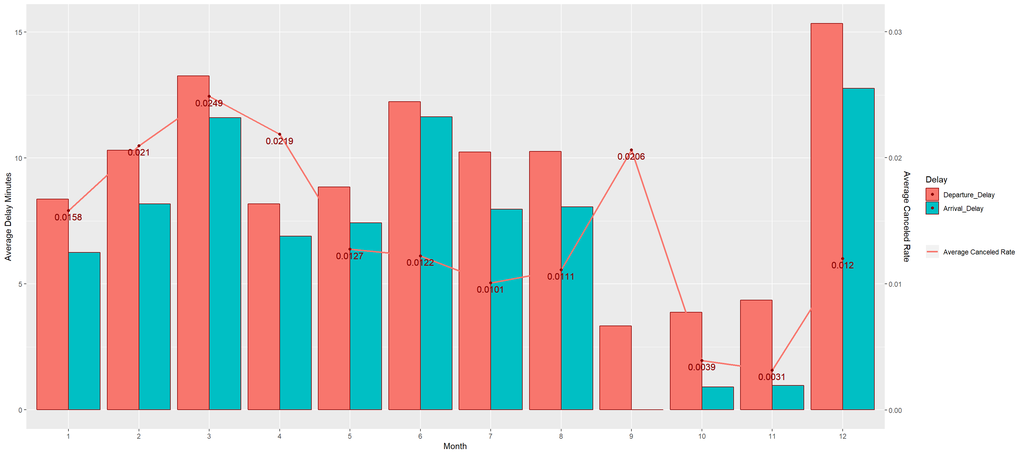

```r
month_mean_depdelay = aggregate(DepDelay~factor(Month), air, mean)
month_mean_arrdelay = aggregate(ArrDelay~factor(Month), air, mean)
month_cancel = aggregate(Cancelled~factor(Month),air,mean)
month_delay_cancel <- cbind(month_cancel,month_mean_depdelay[,2],month_mean_arrdelay[,2])
names(month_delay_cancel) <- c("Month","Cancelled","Departure_Delay","Arrival_Delay")
month_delay_cancel <- melt(month_delay_cancel,id.vars = c(1,2))

update_geom_defaults("bar",   list(colour = "red4"))
ggplot(month_delay_cancel, aes(x=Month,y=value,fill=variable)) +
  ylab("Average Delay Minutes")+
  geom_bar(stat="identity",position = position_dodge())+
  geom_line(aes(y=Cancelled*500,group = 1,color="Average Canceled Rate"),size=1,stat = "identity")+
  geom_point(aes(y = Cancelled*500,group = 1),color="red4")+
  geom_text(aes(y =Cancelled*500,group = 1, label = round(Cancelled, 4)), vjust = 1.4, color = "red4", size = 4)+
  scale_y_continuous(sec.axis = sec_axis(~./500,name="Average Canceled Rate"))+
  scale_fill_discrete(name = "Delay")+
  scale_color_discrete(name = " ")
```

As we can see, Fall is the best season to take a flight, because September, October and November are top 3 months with least average delay time in minutes. These months have only 5 minutes departure delay and the passengers usually can arrived at the destination on time. However, September has a pretty high average cancellation rate. After searching Sep 2008 flights records, we found that the flights were cancelled because of Hurricane Ike. We can also see that December has the most delay minutes.  
For the next part, we wanted to find out which day of the week is the best day to catch a flight.

### Weekday vs Delay and Cancellation

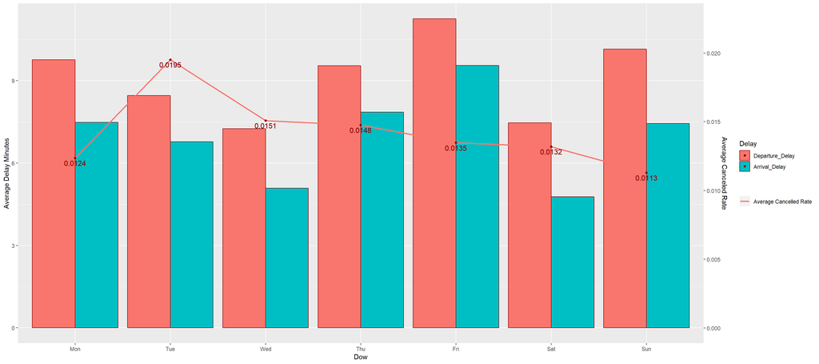

```r
week_mean_depdelay = aggregate(DepDelay~factor(DayOfWeek), air, mean)
week_mean_arrdelay = aggregate(ArrDelay~factor(DayOfWeek), air, mean)
week_cancel = aggregate(Cancelled~factor(DayOfWeek),air,mean)
week_delay_cancel <- cbind(week_cancel,week_mean_depdelay[,2],week_mean_arrdelay[,2])
names(week_delay_cancel) <- c("Dow","Cancelled","Departure_Delay","Arrival_Delay")
week_delay_cancel[1]=c("Mon","Tue","Wed","Thu","Fri","Sat","Sun")
week_delay_cancel <- melt(week_delay_cancel,id.vars = c(1,2))

ggplot(week_delay_cancel, aes(x=Dow,y=value,fill=variable)) +
  ylab("Average Delay Minutes")+
  geom_bar(stat="identity",position = position_dodge())+
  geom_line(aes(y=Cancelled*500,group = 1,color="Average Cancelled Rate"),size=1,stat = "identity")+
  geom_point(aes(y = Cancelled*500,group = 1),color="red4")+
  geom_text(aes(y =Cancelled*500,group = 1, label = round(Cancelled, 4)), vjust = 1.4, color = "red4", size = 4)+
  scale_y_continuous(sec.axis = sec_axis(~./500,name="Average Canceled Rate"))+
  scale_x_discrete(limits=c("Mon","Tue","Wed","Thu","Fri","Sat","Sun"))+
  scale_fill_discrete(name = "Delay")+
  scale_color_discrete(name = " ")
```

We can see that Wednesday and Saturday have the least delay time, but there is not a really significant difference between these days. One thing that is noticeable is that Tuesday has the highest cancellation rate.  
Next, we wanted to explore which airport has the highest delay time and cancellation rate.

### Airport vs Delay and Cancellation

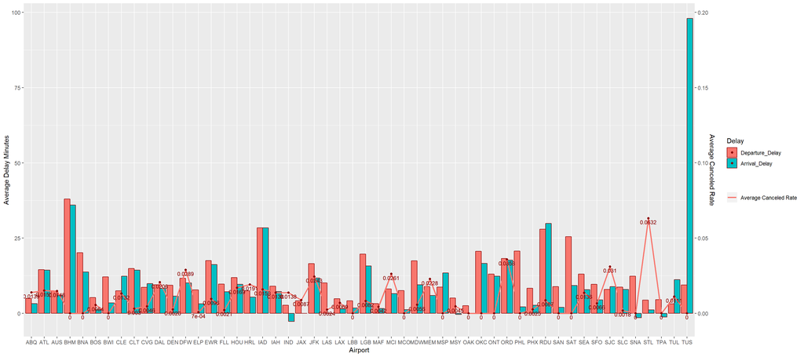

```r
airport_mean_depdelay = aggregate(DepDelay~factor(Origin), air, mean)
airport_mean_arrdelay = aggregate(ArrDelay~factor(Origin), air, mean)
airport_mean_depdelay = airport_mean_depdelay[1:52,]
airport_cancel = aggregate(Cancelled~factor(Origin),air,mean)
airport_cancel = airport_cancel[1:52,]
airport_delay_cancel <- cbind(airport_cancel,airport_mean_depdelay[,2],airport_mean_arrdelay[,2])
names(airport_delay_cancel) <- c("Airport","Cancelled","Departure_Delay","Arrival_Delay")
airport_delay_cancel <- melt(airport_delay_cancel,id.vars = c(1,2))

ggplot(airport_delay_cancel, aes(x=Airport,y=value,fill=variable)) +
  ylab("Average Delay Minutes")+
  geom_bar(stat="identity",position = position_dodge())+
  geom_line(aes(y=Cancelled*500,group = 1,color="Average Canceled Rate"),size=1,stat = "identity")+
  geom_point(aes(y = Cancelled*500,group = 1),color="red4")+
  geom_text(aes(y =Cancelled*500,group = 1, label = round(Cancelled, 4)), vjust = 1.4, color = "red4", size = 3)+
  scale_y_continuous(sec.axis = sec_axis(~./500,name="Average Canceled Rate"))+
  scale_fill_discrete(name = "Delay")+
  scale_color_discrete(name = " ")
```

In this bar chart, we plotted both delay time for origin airport of the flight. As a result, we can figure out if the passengers is in specific airport and have a flight to Austin, how much delay time they should expect. We can see that for TUS airport, the mean arrival delay is almost 100 minutes. That is because that the flights from TUS to Austin are all from XE, which is a private jet company. Because TUS airport is an outlier for our analysis, we tried to create the other plot excluding TUS airport.

### Excluding TUS from Airport Graph

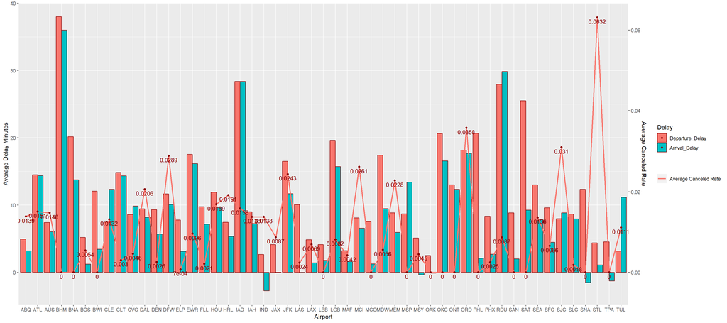

```r
airport_mean_depdelay_notus = airport_mean_depdelay[1:51,]
airport_mean_arrdelay_notus = airport_mean_arrdelay[1:51,]
airport_cancel_notus = airport_cancel[1:51,]
airport_delay_cancel_notus = cbind(airport_cancel_notus,airport_mean_depdelay_notus[,2],airport_mean_arrdelay_notus[,2])
names(airport_delay_cancel_notus) <- c("Airport","Cancelled","Departure_Delay","Arrival_Delay")
airport_delay_cancel_notus <- melt(airport_delay_cancel_notus,id.vars = c(1,2))

ggplot(airport_delay_cancel_notus, aes(x=Airport,y=value,fill=variable)) +
  ylab("Average Delay Minutes")+
  geom_bar(stat="identity",position = position_dodge())+
  geom_line(aes(y=Cancelled*600,group = 1,color="Average Canceled Rate"),size=1,stat = "identity")+
  geom_point(aes(y = Cancelled*600,group = 1),color="red4")+
  geom_text(aes(y =Cancelled*600,group = 1, label = round(Cancelled, 4)), vjust = 1.4, color = "red4", size = 3.5)+
  scale_y_continuous(sec.axis = sec_axis(~./600,name="Average Canceled Rate"))+
  scale_fill_discrete(name = "Delay")+
  scale_color_discrete(name = " ")
```

Now we can see that among all the flights to Austin airport, BHM airport will have the highest average delay time in both departure delay and arrival delay. Although the cancellation rate is 0, the passengers have to wait 38 minutes more for departure. Besides, we found that STL airport has the highest cancellation rate. Despite having low average delay time, STL airport have an average of 6.3% cancellation rate.

## Author attribution

In this part, I will clean the text data, transform as TF-IDF, and construct two models with the first 100 principle components.

#### Import and cleaning:

When importing the document, doc_list is a list of authors.  
Please note that saving any other file under directory of C50train can lead to an importing bug.

```r
library(tm)
library(magrittr)
library(slam)
library(proxy)
library(glmnet)
```

```r
readerPlain = function(fname){
  readPlain(elem=list(content=readLines(fname)),
            id=fname, language='en') }
setwd("../data/ReutersC50/C50train")
doc_list = Sys.glob('*')
file_list = Sys.glob(paste0(doc_list, '/*.txt'))

file_list = Sys.glob(paste0(doc_list, '/*.txt'))
temp = lapply(file_list, readerPlain)


mynames = file_list %>%
{ strsplit(., '/', fixed=TRUE) } %>%
{ lapply(., tail, n=2) } %>%
{ lapply(., paste0, collapse = '') } %>%
  unlist
names(temp) = mynames


documents_raw = VCorpus(VectorSource(temp))

my_documents = documents_raw
my_documents = tm_map(my_documents, content_transformer(tolower))
my_documents = tm_map(my_documents, content_transformer(removeNumbers))
my_documents = tm_map(my_documents, content_transformer(removePunctuation))
my_documents = tm_map(my_documents, content_transformer(stripWhitespace))

DTM = DocumentTermMatrix(my_documents)

DTM = removeSparseTerms(DTM, 0.95)
#Orignal Sparsity is over 90%. To decrease, remove terms that never show up in 95% or more articles.

# construct TF IDF weights
tfidf = weightTfIdf(DTM)
```

For the document cleaning, I DID NOT exclude any stopwords. As IDF will take term frequency accross articles into account, a common but meaningless word tends to have lower TF-IDF. Thus, I’ll let the TF-IDF calculation to do the work.

#### PCA of the training data

```r
# Now PCA on tfidf
X = as.matrix(tfidf)
summary(colSums(X))
```

```
##    Min. 1st Qu.  Median    Mean 3rd Qu.    Max.
##   0.000   3.212   4.356   4.899   5.891  20.616
```

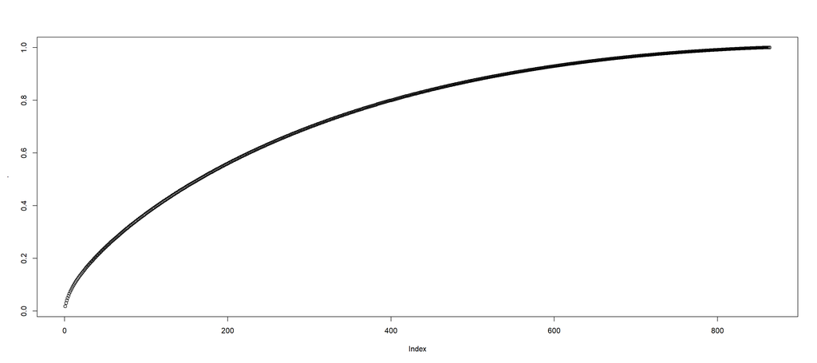

```r
scrub_cols = which(colSums(X) == 0)
X = X[,-scrub_cols]

pca= prcomp(X, scale=TRUE)
summary(pca)$importance[3,]%>%plot()
```

```r
#independent variables: X
X = pca$x[,1:100]

all  <- vector()
i = 1
for (auther in doc_list){
  all[i] = auther
  i = i+1
}

#Model dependent variable: Y
Y = vector()
for( i in 1:2500){
  Y[i] = all[ceiling(i/50)]
}
```

The increasing rate of cumulative explained variance decreases gradually with the number of PCs.  
Considering a balance between variable number and explained variance, I pick up the top 100 PCs, with which 37% variance are explained, to build the model.

#### Test set import and clean

likewisely to the process of train set.

```r
readerPlain = function(fname){
  readPlain(elem=list(content=readLines(fname)),
            id=fname, language='en') }
setwd("../data/ReutersC50/C50test")
doc_list = Sys.glob('*')
file_list = Sys.glob(paste0(doc_list, '/*.txt'))


file_list = Sys.glob(paste0(doc_list, '/*.txt'))
cp2 = lapply(file_list, readerPlain)


mynames = file_list %>%
{ strsplit(., '/', fixed=TRUE) } %>%
{ lapply(., tail, n=2) } %>%
{ lapply(., paste0, collapse = '') } %>%
  unlist
names(cp2) = mynames


documents_raw_1 = VCorpus(VectorSource(cp2))

my_documents1 = documents_raw_1
my_documents1 = tm_map(my_documents1, content_transformer(tolower)) # make everything lowercase
my_documents1 = tm_map(my_documents1, content_transformer(removeNumbers)) # remove numbers
my_documents1 = tm_map(my_documents1, content_transformer(removePunctuation)) # remove punctuation
my_documents1 = tm_map(my_documents1, content_transformer(stripWhitespace)) ## remove excess white-space

DTM_test = DocumentTermMatrix(my_documents1,control = list(dictionary=Terms(DTM)))
DTM_test = removeSparseTerms(DTM_test, 0.95)

tfidf_test = weightTfIdf(DTM_test)

X_test = as.matrix(tfidf_test)
scrub_cols = which(colSums(X_test) == 0)
X_test = X_test[,-scrub_cols]
```

Now, X_test is our TF-IDF of the test file. As our model will be based on the 100 PCs of training set, we need to calculate the linear combination of the test set TF-IDF with the loadings of 100 PCs of trainings set before making prediction.

```r
####Matching the column name of test TFIDF to the Train TFIDF
train_pre_pc = as.matrix(tfidf)
scrub_cols = which(colSums(train_pre_pc) == 0)
train_pre_pc = train_pre_pc[,-scrub_cols]

train_name = colnames(train_pre_pc)
test_name = colnames(X_test)
sup = setdiff(train_name, test_name)

temp_x = data.frame(X_test)
for (colname_ in sup){
  temp_x[,colname_] = 0
}

##somehow there is still difference
#This can be identified using:
#setdiff(colnames(t), train_name)

#hereby I manually fix them
colnames(temp_x)[colnames(temp_x)=="for."] <- "for"
colnames(temp_x)[colnames(temp_x)=="next."] <- "next"
colnames(temp_x)[colnames(temp_x)=="while."] <- "while"
t = data.matrix(temp_x)
t <- t[, order(colnames(t))]
#####

#transform the test set to the principal component spaces of the training set
test.data <- predict(pca, newdata =t)
test.data <- as.data.frame(test.data)
test.data <- test.data[,1:100]
```

test.data is the X of test_set for our model to predict.

#### Model: Logistics LASSO

```r
library(MLmetrics)
library(caret)
out1 = glmnet(X, factor(Y), family="multinomial")
p1 = predict(out1, data.matrix(test.data), s=0.01, type = "response")

myPredict_for_out1 <- function(which_article){
  return(which.max(p1[which_article,,]))
}

Ya  <- vector()
i = 1
for (auther in doc_list){
  Ya[i] = auther
  i = i+1
}

#real is the true values
real = vector()
for( i in 1:2500){
  real[i] = Ya[ceiling(i/50)]
}

#aut is our prediction
aut = vector()
for (i in 1:2500){
  aut[i] =names(myPredict_for_out1(i))
}

Accuracy(aut, real)
```

```
## [1] 0.416
```

```r
(table(aut,real)%>%confusionMatrix)$byClass[,"Balanced Accuracy"]
```

```
##     Class: AaronPressman        Class: AlanCrosby    Class: AlexanderSmith
##                0.8646939                0.6275510                0.7381633
##   Class: BenjaminKangLim     Class: BernardHickey       Class: BradDorfman
##                0.6642857                0.5804082                0.5848980
##  Class: DarrenSchuettler       Class: DavidLawder     Class: EdnaFernandes
##                0.6559184                0.5442857                0.5379592
##       Class: EricAuchard    Class: FumikoFujisaki    Class: GrahamEarnshaw
##                0.5838776                0.9234694                0.8342857
##  Class: HeatherScoffield     Class: JaneMacartney        Class: JanLopatka
##                0.6414286                0.5079592                0.6738776
##      Class: JimGilchrist          Class: JoeOrtiz      Class: JohnMastrini
##                0.8969388                0.5385714                0.6646939
##      Class: JonathanBirt    Class: JoWinterbottom       Class: KarlPenhaul
##                0.7410204                0.8328571                0.8065306
##         Class: KeithWeir    Class: KevinDrawbaugh     Class: KevinMorrison
##                0.6473469                0.6020408                0.5973469
##     Class: KirstinRidley Class: KouroshKarimkhany         Class: LydiaZajc
##                0.6871429                0.8185714                0.8087755
##    Class: LynneO'Donnell   Class: LynnleyBrowning   Class: MarcelMichelson
##                0.8826531                0.9434694                0.7746939
##      Class: MarkBendeich        Class: MartinWolk      Class: MatthewBunce
##                0.7132653                0.5461224                0.9053061
##     Class: MichaelConnor        Class: MureDickie         Class: NickLouth
##                0.7442857                0.7285714                0.8212245
##   Class: PatriciaCommins     Class: PeterHumphrey        Class: PierreTran
##                0.6161224                0.8557143                0.6955102
##        Class: RobinSidel      Class: RogerFillion       Class: SamuelPerry
##                0.9026531                0.8065306                0.6055102
##      Class: SarahDavison       Class: ScottHillis       Class: SimonCowell
##                0.6883673                0.5195918                0.6057143
##          Class: TanEeLyn    Class: TheresePoletti        Class: TimFarrand
##                0.5634694                0.6202041                0.7871429
##        Class: ToddNissen      Class: WilliamKazer
##                0.6620408                0.5089796
```

Out-of-sample overall accuracy is around 41%. The baseline in this prediction is 1/50, which is 2%. To improve the accuracy, one may cross validate on LASSO lambda. Due to limited computation ability, current lambda is only based on manual adjustment.  
“Balanced Accuracy = (sensitivity+specificity)/2”  
Though the overall accuracy is only 41%, the model performs well in term of Sensitivity and Specificity, according to the balanced accuracy(50%~90%). That is, the proportion of actual positives/negatives that are correctly identified is high.

#### Model: Random Forest

```r
library(randomForest)
fY = factor(Y)
dfX =data.frame(X)
XY = cbind(dfX, fY)

rffit = randomForest(fY~.,data=XY,ntree=500)
prf<- predict(rffit, newdata = test.data)
Accuracy(prf, factor(real))
```

```
## [1] 0.52
```

```r
(table(prf,real)%>%confusionMatrix)$byClass[,"Balanced Accuracy"]
```

```
##     Class: AaronPressman        Class: AlanCrosby    Class: AlexanderSmith
##                0.8781633                0.7989796                0.7157143
##   Class: BenjaminKangLim     Class: BernardHickey       Class: BradDorfman
##                0.6332653                0.6677551                0.7222449
##  Class: DarrenSchuettler       Class: DavidLawder     Class: EdnaFernandes
##                0.6069388                0.5475510                0.5779592
##       Class: EricAuchard    Class: FumikoFujisaki    Class: GrahamEarnshaw
##                0.6353061                0.9363265                0.8842857
##  Class: HeatherScoffield     Class: JaneMacartney        Class: JanLopatka
##                0.6630612                0.6767347                0.6381633
##      Class: JimGilchrist          Class: JoeOrtiz      Class: JohnMastrini
##                0.9377551                0.6634694                0.8151020
##      Class: JonathanBirt    Class: JoWinterbottom       Class: KarlPenhaul
##                0.7930612                0.8379592                0.9032653
##         Class: KeithWeir    Class: KevinDrawbaugh     Class: KevinMorrison
##                0.8463265                0.7581633                0.7626531
##     Class: KirstinRidley Class: KouroshKarimkhany         Class: LydiaZajc
##                0.8169388                0.8063265                0.8100000
##    Class: LynneO'Donnell   Class: LynnleyBrowning   Class: MarcelMichelson
##                0.8979592                0.9310204                0.7269388
##      Class: MarkBendeich        Class: MartinWolk      Class: MatthewBunce
##                0.7175510                0.6487755                0.9181633
##     Class: MichaelConnor        Class: MureDickie         Class: NickLouth
##                0.7965306                0.6742857                0.8146939
##   Class: PatriciaCommins     Class: PeterHumphrey        Class: PierreTran
##                0.6663265                0.9083673                0.7942857
##        Class: RobinSidel      Class: RogerFillion       Class: SamuelPerry
##                0.8855102                0.7975510                0.7326531
##      Class: SarahDavison       Class: ScottHillis       Class: SimonCowell
##                0.7257143                0.5065306                0.7846939
##          Class: TanEeLyn    Class: TheresePoletti        Class: TimFarrand
##                0.6383673                0.7165306                0.7816327
##        Class: ToddNissen      Class: WilliamKazer
##                0.7820408                0.5755102
```

#### So, are there any sets of authors whose articles seem difficult to distinguish from one another?

```r
cosine_docs = function(dtm) {
  crossprod_simple_triplet_matrix(t(dtm))/(sqrt(col_sums(t(dtm)^2) %*% t(col_sums(t(dtm)^2))))
}

# use the function to compute pairwise cosine similarity for all documents
cosine_mat = cosine_docs(tfidf)

myStore = data.frame()
for(i in 1:2500){
  myStore[i,1] = as.numeric(i)
  myStore[i,2] = as.numeric(sort(cosine_mat[i,], decreasing=F)[1]%>%names)
  myStore[i,3] = sort(cosine_mat[i,], decreasing=F)[1]
}
colnames(myStore)<- c("Article_1", "Article_2", "Cosine_Distance")

#These are the articles who are very similar to each other
myrank = myStore[order(myStore$Cosine_Distance),]
#drop reversed duplicates
temp1 = apply(myrank[,1:2],1,function(x) paste(sort(x),collapse=''))
#These are the articles who are very similar, even identical, to each other
(myrank[!duplicated(gsub(" ", "", temp1, fixed = TRUE)),])[1:10,]
```

```
##      Article_1 Article_2 Cosine_Distance
## 6            6       615    0.000000e+00
## 764        764         6    0.000000e+00
## 765        765         6    0.000000e+00
## 1206      1206      1681    0.000000e+00
## 2187      2187      1681    0.000000e+00
## 800        800      2393    2.792552e-08
## 212        212       765    1.206647e-07
## 1513      1513       615    1.921827e-07
## 602        602      2393    2.364743e-07
## 780        780       615    2.912278e-07
```

```r
#These are the corresponding authers
myrank1 = myrank[!duplicated(gsub(" ", "", temp1, fixed = TRUE)),]
myrank1$Article_1 = ceiling(myrank1$Article_1/50)
myrank1$Article_2 = ceiling(myrank1$Article_2/50)
myrank1 = myrank1[order(myrank1$Cosine_Distance),]


#pragma only after myrank1 defined
myThreshold<- function(threshold){
  local_df = myrank1[myrank1[,3]<threshold,]
  tr = apply(local_df[,1:2],1,function(x) paste(sort(x),collapse='-'))%>%table
  return(tr[order(tr, decreasing = TRUE)])
}

#These are the authers have lots of similar articles
myThreshold(0.001)%>%head
```

```
## .
##  1-14 16-34 16-40  1-11  1-16   1-4
##     8     7     6     5     5     5
```

## Practice with association rule mining

```r
library(tidyverse)
library(arules)
library(arulesViz)
```

```r
groceries_raw = read.transactions("https://raw.githubusercontent.com/jgscott/STA380/master/data/groceries.txt", sep = ",")
str(groceries_raw)
```

```
## Formal class 'transactions' [package "arules"] with 3 slots
##   ..@ data       :Formal class 'ngCMatrix' [package "Matrix"] with 5 slots
##   .. .. ..@ i       : int [1:43367] 29 88 118 132 33 157 167 166 38 91 ...
##   .. .. ..@ p       : int [1:9836] 0 4 7 8 12 16 21 22 27 28 ...
##   .. .. ..@ Dim     : int [1:2] 169 9835
##   .. .. ..@ Dimnames:List of 2
##   .. .. .. ..$ : NULL
##   .. .. .. ..$ : NULL
##   .. .. ..@ factors : list()
##   ..@ itemInfo   :'data.frame':  169 obs. of  1 variable:
##   .. ..$ labels: chr [1:169] "abrasive cleaner" "artif. sweetener" "baby cosmetics" "baby food" ...
##   ..@ itemsetInfo:'data.frame':  0 obs. of  0 variables
```

```r
summary(groceries_raw)
```

```
## transactions as itemMatrix in sparse format with
##  9835 rows (elements/itemsets/transactions) and
##  169 columns (items) and a density of 0.02609146
##
## most frequent items:
##       whole milk other vegetables       rolls/buns             soda
##             2513             1903             1809             1715
##           yogurt          (Other)
##             1372            34055
##
## element (itemset/transaction) length distribution:
## sizes
##    1    2    3    4    5    6    7    8    9   10   11   12   13   14   15
## 2159 1643 1299 1005  855  645  545  438  350  246  182  117   78   77   55
##   16   17   18   19   20   21   22   23   24   26   27   28   29   32
##   46   29   14   14    9   11    4    6    1    1    1    1    3    1
##
##    Min. 1st Qu.  Median    Mean 3rd Qu.    Max.
##   1.000   2.000   3.000   4.409   6.000  32.000
##
## includes extended item information - examples:
##             labels
## 1 abrasive cleaner
## 2 artif. sweetener
## 3   baby cosmetics
```

```r
groceries_raw <- as (groceries_raw, "transactions")

freqItems = eclat(groceries_raw, parameter = list(supp = .07, maxlen = 15))
```

```
## Eclat
##
## parameter specification:
##  tidLists support minlen maxlen            target   ext
##     FALSE    0.07      1     15 frequent itemsets FALSE
##
## algorithmic control:
##  sparse sort verbose
##       7   -2    TRUE
##
## Absolute minimum support count: 688
##
## create itemset ...
## set transactions ...[169 item(s), 9835 transaction(s)] done [0.00s].
## sorting and recoding items ... [18 item(s)] done [0.00s].
## creating sparse bit matrix ... [18 row(s), 9835 column(s)] done [0.00s].
## writing  ... [19 set(s)] done [0.00s].
## Creating S4 object  ... done [0.00s].
```

```r
inspect(freqItems)
```

```
##      items                         support    count
## [1]  {other vegetables,whole milk} 0.07483477  736
## [2]  {whole milk}                  0.25551601 2513
## [3]  {other vegetables}            0.19349263 1903
## [4]  {rolls/buns}                  0.18393493 1809
## [5]  {yogurt}                      0.13950178 1372
## [6]  {soda}                        0.17437722 1715
## [7]  {root vegetables}             0.10899847 1072
## [8]  {tropical fruit}              0.10493137 1032
## [9]  {bottled water}               0.11052364 1087
## [10] {sausage}                     0.09395018  924
## [11] {shopping bags}               0.09852567  969
## [12] {citrus fruit}                0.08276563  814
## [13] {pastry}                      0.08896797  875
## [14] {pip fruit}                   0.07564820  744
## [15] {whipped/sour cream}          0.07168277  705
## [16] {fruit/vegetable juice}       0.07229283  711
## [17] {newspapers}                  0.07981698  785
## [18] {bottled beer}                0.08052872  792
## [19] {canned beer}                 0.07768175  764
```

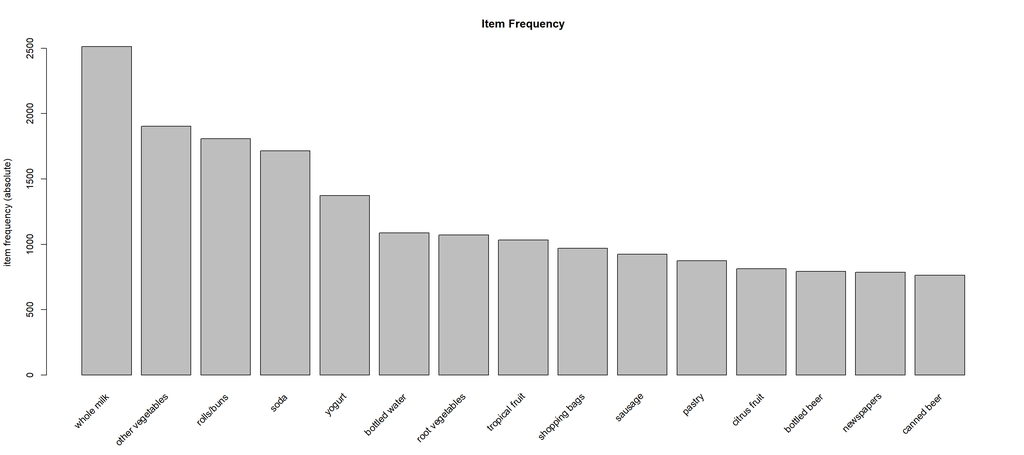

```r
itemFrequencyPlot(groceries_raw, topN=15, type="absolute", main="Item Frequency")
```

We set the parameters to plot top 15 groceries with the largest number of counts in dataset. Based on summary above and this plot of transaction data, ‘wholemilk’ has the biggest frequency and ‘other vegetables’ category follows. This might impact the result of our analysis.

We tried several models with different support and confidence level and found 0.15% of support and 60% of confidence level returns the most interesting and distinguishable result. We also set ‘manlen=3’ since, assuming the retail company puts products in a row at each aisle, retail company often asks that which product should they put on the left and right side of the section. For this practical reason, we choose maxlen=3.

```r
rules <- apriori (groceries_raw, parameter = list(supp = 0.0015, conf = 0.60, maxlen = 3))
```

```
## Apriori
##
## Parameter specification:
##  confidence minval smax arem  aval originalSupport maxtime support minlen
##         0.6    0.1    1 none FALSE            TRUE       5  0.0015      1
##  maxlen target   ext
##       3  rules FALSE
##
## Algorithmic control:
##  filter tree heap memopt load sort verbose
##     0.1 TRUE TRUE  FALSE TRUE    2    TRUE
##
## Absolute minimum support count: 14
##
## set item appearances ...[0 item(s)] done [0.00s].
## set transactions ...[169 item(s), 9835 transaction(s)] done [0.00s].
## sorting and recoding items ... [153 item(s)] done [0.00s].
## creating transaction tree ... done [0.00s].
## checking subsets of size 1 2 3
```

```
##  done [0.00s].
## writing ... [255 rule(s)] done [0.00s].
## creating S4 object  ... done [0.00s].
```

```r
rules_conf <- sort(rules, by="lift", decreasing = TRUE)
inspect(rules_conf)
```

```
##       lhs                           rhs                    support confidence      lift count
## [1]   {ham,
##        processed cheese}         => {white bread}      0.001931876  0.6333333 15.045491    19
## [2]   {liquor,
##        red/blush wine}           => {bottled beer}     0.001931876  0.9047619 11.235269    19
## [3]   {rice,
##        yogurt}                   => {root vegetables}  0.001626843  0.6956522  6.382219    16
## [4]   {root vegetables,
##        turkey}                   => {tropical fruit}   0.001525165  0.6000000  5.718023    15
## [5]   {herbs,
##        tropical fruit}           => {root vegetables}  0.001728521  0.6071429  5.570196    17
## [6]   {herbs,
##        rolls/buns}               => {root vegetables}  0.001830198  0.6000000  5.504664    18
## [7]   {curd,
##        soft cheese}              => {yogurt}           0.001525165  0.6818182  4.887523    15
## [8]   {fruit/vegetable juice,
##        soft cheese}              => {yogurt}           0.001830198  0.6666667  4.778912    18
## [9]   {butter milk,
##        pork}                     => {other vegetables} 0.001830198  0.8571429  4.429848    18
## [10]  {margarine,
##        meat}                     => {other vegetables} 0.001728521  0.8500000  4.392932    17
## [11]  {rice,
##        yogurt}                   => {other vegetables} 0.001931876  0.8260870  4.269346    19
## [12]  {herbs,
##        shopping bags}            => {other vegetables} 0.001931876  0.8260870  4.269346    19
## [13]  {onions,
##        sliced cheese}            => {other vegetables} 0.001525165  0.7894737  4.080123    15
## [14]  {root vegetables,
##        turkey}                   => {other vegetables} 0.001931876  0.7600000  3.927798    19
## [15]  {soft cheese,
##        whipped/sour cream}       => {other vegetables} 0.002236909  0.7333333  3.789981    22
## [16]  {frozen vegetables,
##        soft cheese}              => {other vegetables} 0.001626843  0.7272727  3.758659    16
## [17]  {root vegetables,
##        soft cheese}              => {other vegetables} 0.002440264  0.7272727  3.758659    24
## [18]  {grapes,
##        pork}                     => {other vegetables} 0.001626843  0.7272727  3.758659    16
## [19]  {citrus fruit,
##        herbs}                    => {other vegetables} 0.002135231  0.7241379  3.742457    21
## [20]  {baking powder,
```

[output cut: 454 more lines]

```
##        white bread}              => {whole milk}       0.001525165  0.6000000  2.348189    15
## [249] {hard cheese,
##        newspapers}               => {whole milk}       0.001525165  0.6000000  2.348189    15
## [250] {coffee,
##        sliced cheese}            => {whole milk}       0.001525165  0.6000000  2.348189    15
## [251] {oil,
##        pastry}                   => {whole milk}       0.001830198  0.6000000  2.348189    18
## [252] {oil,
##        rolls/buns}               => {whole milk}       0.003050330  0.6000000  2.348189    30
## [253] {hamburger meat,
##        margarine}                => {whole milk}       0.001830198  0.6000000  2.348189    18
## [254] {coffee,
##        napkins}                  => {whole milk}       0.002440264  0.6000000  2.348189    24
## [255] {beef,
##        tropical fruit}           => {whole milk}       0.004575496  0.6000000  2.348189    45
```

Among top 10 assciations with highest lift, we found few interesting facts.  
First, considering high association between ‘ham, processed cheese’ and ‘white bread’, this retail company should place few selections of white bread neary by ‘ham and processed cheese’ section for customers who want to make ham-cheese sandwiches. Since bread doesn’t require any thermoregulation, the company can easily place small shelf for bread. Since many people buy things impulsively, this placement might only directly target customers who were look for ham-cheese sandwich previously but also remind them ham-cheese sandwiches. From the 4th association, many people buy turkey, vegetables and tropical fruit together and this combination seems to be a common lunch box; turkey sandwich with bananas. Since those associations are combinations with clear intentions, the compamy can not only place them together, but also do some marketing which helps people to remind ‘ham-cheese sandwich’ or ‘turkey sandwich lunch box’.

The 9th and 10th association, however, show that customers who bought meat and dairy products, they are 4 times more likely to buy vegetables. Based on this fact, the company may should put three sections together for sale increase effect from complementary goods.